# Algoritma Academy: Programming for Data Science

Samuel Chan

Updated: June 23, 2018

Before you go ahead and run the codes in this coursebook, it’s often a good idea to go through some initial setup. Under the *Libraries and Setup* tab you’ll see some code to initialize our workspace, and the libraries we’ll be using for the projects. You may want to make sure that the libraries are installed beforehand by referring back to the packages listed here. Under the *Training Focus* tab we’ll outline the syllabus, identify the key objectives and set up expectations for each module.

# 1 Background

## 1.1 Algoritma

The following coursebook is produced by the team at [Algoritma](https://algorit.ma) for its Data Science Academy workshops. The coursebook is intended for a restricted audience only, i.e. the individuals and organizations having received this coursebook directly from the training organization. It may not be reproduced, distributed, translated or adapted in any form outside these individuals and organizations without permission.

Algoritma is a data science education center based in Jakarta. We organize workshops and training programs to help working professionals and students gain mastery in various data science sub-fields: data visualization, machine learning, data modeling, statistical inference etc.

## 1.2 Libraries and Setup

We’ll set-up caching for this notebook given how computationally expensive some of the code we will write can get.

```r
knitr::opts_chunk$set(cache=TRUE)
options(scipen = 9999)
rm(list=ls())
```

You will need to use `install.packages()` to install any packages that are not already downloaded onto your machine. You then load the package into your workspace using the `library()` function:

```r
library(skimr)
library(dplyr)
```

## 1.3 Training Objectives

The primary objective of this course is to provide a comprehensive introduction to the science of statistical programming and the toolsets required to succeed with data science work. The syllabus covers:

- **Programming languages and Tools**
- R Programming
- Workflow and Tools Setup
- Data Structures in R
- Python Programming
- R Scripts and R Markdown
- **Data Manipulation**
- Read & Extracting Data
- Practical Data Cleansing
- Data Transformation
- **Statistical Computing**
- Organizing your Project
- Modern Tools for Data Analysis
- Reproducible Data Science

By the end of the workshop, Academy students can choose to complete either of the Learn-By-Building modules as their graded assignment:

**R Script to clean & transform the data**  
A programming script that perform various data cleansing tasks and output the result in an appropriate format for further data science work.

**Reproducible Data Science**  
Create an R Markdown file that combines data transformation code with explanatory text. Add formatting styles and hierarchical structure using Markdown.

# 2 R Programming

Since you’ll spend a great deal of your time working with data in R and RStudio, I think it’s important to get yourself very familiar with this IDE (integrated development environment). RStudio is the most popular integrated development for R and is a core tool for data science teams in AirBnB[^1], Uber[^2] etc., and is a tool we’ll be using throughout the Academy workshops.

If you’re a seasoned programmer, the **Option + Shift + K** combination will bring up a shortcut reference guide that helps you use RStudio more effectively.

## 2.2 R Programming Basics

It pays to get yourself familiar with R and RStudio, the IDE (interactive development environment). In our workshop, we’ll discuss in more details the various functionalities of RStudio’s interface, and if this is the first time you’re working in a code environment, it pays to get yourself familiar with this IDE as you’ll be working with it a lot!

To get started, let’s write our first R code by typing `getwd()` into the Console (bottom of the screen), or by running in from within a Chunk (look for the green “run” button):

```r
# This is a comment
getwd()
```

```
## [1] "C:/Users/Algoritma/Documents/P4DS (2)/P4DS"
```

```r
# setwd(...)
```

Notice the “#” character in the first and third line of the code chunk, indicating to R that it’s a comment and should be ignored. `setwd()` was ignored because it’s on the same line and to the right of the “#” character. As you may have expected, `setwd()` is used to change our working directory by setting a new one.

R is **case-sensitive** so “Algoritma” and “algoritma” are different symbols and will point to different variables.

```r
activity <- "Programming"
activity == "programming"
```

```
## [1] FALSE
```

```r
print(paste(activity, "is one of the most therapeutic activity."))
```

```
## [1] "Programming is one of the most therapeutic activity."
```

```r
# Object 'Activity' don't exist!
# print(Activity) will not work
```

### 2.2.1 Vectors

Speaking of objects, R objects can take on one of five classes:  
- character  
- numeric  
- integer  
- complex  
- logical

The most basic form of an R object is a vector. As a rule, a vector can only contain objects of the same class:

```r
vector1 <- c("learning", "data", "science", 2018)
class(vector1)
```

```
## [1] "character"
```

```r
vector2 <- c(1, FALSE, FALSE, 0)
class(vector2)
```

```
## [1] "numeric"
```

Also observe how we use the `c()` function to concatenate objects together to form a vector.

`vector1` is now an object in our global environment, but if you’re paying attention, you’ll notice that it is a **character vector**. While 2018 itself is a numeric, because of the “same-class” rule we learn above, 2018 was coerced into a character so that the resulting vector is valid. 2018 (the numeric) is “2018” (character) as a result:

```r
vector1
```

```
## [1] "learning" "data"     "science"  "2018"
```

Similarly, in `vector2`, `1` is a numeric, and `FALSE` is a logical, and therefore the `FALSE` values are coerced into a numeric. Go ahead and print out `vector2` as a confirmation:

```r
# your code here:
```

R objects may have attributes like `names`, `class`, `length`, `colnames`, `dim` etc:

```r
names(vector2) <- c("User ID", "Active", "Cart Items", "Payment")
length(vector2)
```

```
## [1] 4
```

```r
vector2
```

```
##    User ID     Active Cart Items    Payment
##          1          0          0          0
```

Recall how implicit coercion (R’s default) takes place earlier when we create our `vector1` and `vector2`. We could explicitly coerce one class to another:

```r
vector2 <- c(1,FALSE,FALSE,0)
vector2.b <- as.logical(vector2)
vector2.b
```

```
## [1]  TRUE FALSE FALSE FALSE
```

```r
class(vector2.b)
```

```
## [1] "logical"
```

**Dive Deeper:**  
Create a vector and name it `customers`. Store 4 names in the vector and make sure it is a `character` vector. Create another vector and name it `age`, store 4 numeric in the vector and make sure it is a `numeric` vector.

```r
# Your code here:
```

2. Use `class()` and `length()` in the code chunk below to verify that you have done the exercise above correctly:

```r
# Your code here:
```

3. Create another vector and name it `suppliers`. Store 3 names in it:

```r
# Your code here
```

4. Join the `customers` and `suppliers` vector into one vector using the concatenate technique you’ve learned, which is `c()`.

```r
# Your code here:
```

If you’ve managed to execute the above exercises in the dive deeper section: congratulations! Throughout the course you’ll do a number of these exercises, and they are useful revision tools that you should take advantage of to test your knowledge and make sure you have a full grasp of the topics being assessed.

You’ve see how numeric and character classes and even made a few vectors of your own above! But R has other object types and we’ll take a look at them:

```r
# character
tempo <- c("Algoritma", "Indonesia", "e-Commerce", "Jakarta")
# numeric
tempo <- c(-1, 1, 2, 3/4, 0.5)
# integer
tempo <- c(1L, 2L)
# integer
tempo <- 5:8
# complex
tempo <- c(1+3i, (1+3i)*2)
# logical
tempo <- c(TRUE, TRUE, FALSE)
```

A quick note on integers: they cannot take decimal or fractional values, while numerics can. Numerics act more like the “float” or “double” types supported by many other programming languages.

### 2.2.2 Matrix

When we create a vector and give it a dimension attribute, we end up with a matrix:

```r
matri <- matrix(11:16, nrow=3, ncol=2)
dim(matri)
```

```
## [1] 3 2
```

```r
matri
```

```
##      [,1] [,2]
## [1,]   11   14
## [2,]   12   15
## [3,]   13   16
```

Notice how the values fill up by column from the [1,1] position, which is the most upper-left position.

Once created, we can refer to any row or column using R’s subsetting operator:

```r
matri[1,]
```

```
## [1] 11 14
```

```r
matri[,2]
```

```
## [1] 14 15 16
```

We could also have constructed a matrix by giving an existing vector the `dim` attribute:

```r
numbers <- 11:16
dim(numbers) <- c(2,3)
numbers
```

```
##      [,1] [,2] [,3]
## [1,]   11   13   15
## [2,]   12   14   16
```

Notice `c(2,3)` means “2 rows, 3 columns”. Contrast this to our `matri` object above and the way we constructed matrices using two different approach.

Another interesting way to construct a matrix:

```r
accounts <- c("AlphaMall", "BetaMall", "OmegaMall")
sales <- c(400,320,380)
returns <- c(0,0,480)
netsales <- sales - returns
# cbind = bind as columns
# rbind = bind as rows
# rbind(accounts, sales, returns)

sales_records <- cbind(accounts, sales, netsales)
```

`sales_record` is now a matrix. Go ahead and print it, then observe how 400 (numeric) has been coerced into “400” (strings) so the resulting matrix is a valid R object.

**Dive Deeper:**  
1. You learned how to bind the three vectors by columns. Now create a matrix named `sales_records` and bind `sales`, `returns` and `netsales` by rows (instead of columns). You can do this with `rbind` (row-bind)

```r
# Your code here
```

2. You can optionally check that you’ve done the above step correctly by printing out the matrix and / or use `dim()` to verify that is in fact a 3x3 matrix. Now assign `accounts` as column names to your matrix. To assign column names to a matrix, we can use `colnames(mymatrix) <- c("Name1", "Name2", "Name3")`:

```r
# Your code here
```

3. Print our `sales_records`:

```r
# Your code here
```

### 2.2.4 List

There is a type of R object that is exempted from the rule we repeatedly mention above, and it’s the **List**:

```r
our.list <- list(TRUE, "TRUE", c(1,6,12), 1+5i)
our.list
```

```
## [[1]]
## [1] TRUE
##
## [[2]]
## [1] "TRUE"
##
## [[3]]
## [1]  1  6 12
##
## [[4]]
## [1] 1+5i
```

A list, as we’ve observed above, can contain elements that are of different classes from other members of the list. You can can subset from a list much like how you’ve done earlier: however, any subsets using a single square bracket `[]` will return a list. To return the elements itself, use double square-brackets: `[[]]`

Demonstration of subsetting elements from our list:

```r
our.list[3]
```

```
## [[1]]
## [1]  1  6 12
```

```r
our.list[[3]]
```

```
## [1]  1  6 12
```

```r
class(our.list[3])
```

```
## [1] "list"
```

```r
class(our.list[[3]])
```

```
## [1] "numeric"
```

### 2.2.5 Factors

Another important concept in R is factors - many statistical modeling techniques and prediction algorithms treat factors specially either as a target outcome (in machine learning language) or dependent variable (in statistics) while many other modeling techniques treat factors specially when they’re used as independent variables. Factors is useful in representing categorical variables whether or not they are unordered (cash, credit, transfer) or ordered (high volume, normal volume, low volume):

```r
categories <- factor(c("OfficeSupplies", "Computers", "Packaging", "Machinery", "Building"))
categories # levels are sorted alphabetically unless through the levels argument
```

```
## [1] OfficeSupplies Computers      Packaging      Machinery
## [5] Building
## Levels: Building Computers Machinery OfficeSupplies Packaging
```

### 2.2.6 Data Frames

Data frames can be thought of as a special case of lists where every element of the list has to have the same length. Each element of the list can be thought of as a column in the data frame.

```r
categories_df <- data.frame(categories=c("OfficeSupplies", "Computers", "Packaging", "Machinery", "Building"), category_id=111:115)
categories_df
```

```
##       categories category_id
## 1 OfficeSupplies         111
## 2      Computers         112
## 3      Packaging         113
## 4      Machinery         114
## 5       Building         115
```

And we can perform mathematical operations on our dataframes, the same way we can do it with matrices. If we need to update our system by adding one new category on the top of the list such that all existing IDs are incremented by one, we can do so:

```r
categories_df$category_id + 1
```

```
## [1] 112 113 114 115 116
```

Notice that here we’re accessing the `category_id` column using the ‘$’ operator.

```r
class(1-TRUE)
```

```
## [1] "numeric"
```

```r
TRUE + TRUE * 34
```

```
## [1] 35
```

# 3 R Programming with Retail Dataset

With the foundations laid, let’s now take a look at a real life dataset and apply our newly acquired knowledge.

First make sure the data you’ll like to work with is also in your current directory, and use the `read.csv()` to read our csv file into your global environment. Having our CSV in the same directory as the one we’re working in isn’t required, we may have used the full path as well. However, to keep our projects organized I would recommend you keep your scripts, working files, and its dependent data in the same directory whenever it’s convenient to do so:

```r
retail <- read.csv("data_input/retail.csv")
names(retail)
```

```
##  [1] "Row.ID"       "Order.ID"     "Order.Date"   "Ship.Date"
##  [5] "Ship.Mode"    "Customer.ID"  "Segment"      "Product.ID"
##  [9] "Category"     "Sub.Category" "Product.Name" "Sales"
## [13] "Quantity"     "Discount"     "Profit"
```

The two lines of code above does two things:  
- Read our csv file into R so we can begin working on it  
- Use `names()` to get the names of our dataset variable

If you have tried calling `names(Retail)` you would have gotten an error that says `object 'Retail' not found`. This is because R is case-sensitive, so `Retail` and `retail` are different things. Correct the following code so it prints the dimensions of the dataframe:

```r
# Will throw an error: Retail not found
dim(Retail)
```

Notice also that R commands are separated either by a semi-colon (‘;’), or by a newline. So we can write our code like the above, or we could have separate the commands with ‘;’. For the most part, we will stick to writing code using the new line format as it makes our code more readable. An example of two commands on the same line:

```r
purchases <- 15; purchases * 2;
```

```
## [1] 30
```

**Dive Deeper: Inspect the structure of the data using `str()`**  
Call `str()` on our `retail` dataset the same way you use `names()`. `str()` returns the structure of an R Object and we’ll be using it a lot given how helpful that is.

```r
# Your code here
```

Now if you’ve previously been working with data in a speadsheet-like environment, using `names()` and `str()` to inspect data may taking a bit of getting used to - however, I can assure you the benefits will become apparent (from a programmability perspective but also, very soon, you’ll be dealing with data with thousands of variables and a spreadsheet environment just isn’t going to make much sense). For a relatively small dataset as this, you can still view the full CSV in its raw format through the `View(retail)` command, or clicking on the “spreadsheet” icon next to the data you’ll like to inspect in the Environment pane.

I don’t recommend you use the `View()` command, because in real life you don’t always know beforehand the size of data, and I think taking a peek at the first few rows of data would suffice. To see the first 6 observations, we could have just done `head(retail)`. We can pass in an extra argument, *n*, so the function would return the first *n* number of rows instead of the default 6. The following code returns the first 5 rows of our data:

```r
head(retail, 5)
```

```
##   Row.ID       Order.ID Order.Date Ship.Date      Ship.Mode Customer.ID
## 1      1 CA-2016-152156    11/8/16  11/11/16   Second Class    CG-12520
## 2      2 CA-2016-152156    11/8/16  11/11/16   Second Class    CG-12520
## 3      3 CA-2016-138688    6/12/16   6/16/16   Second Class    DV-13045
## 4      4 US-2015-108966   10/11/15  10/18/15 Standard Class    SO-20335
## 5      5 US-2015-108966   10/11/15  10/18/15 Standard Class    SO-20335
##     Segment      Product.ID        Category Sub.Category
## 1  Consumer FUR-BO-10001798       Furniture    Bookcases
## 2  Consumer FUR-CH-10000454       Furniture       Chairs
## 3 Corporate OFF-LA-10000240 Office Supplies       Labels
## 4  Consumer FUR-TA-10000577       Furniture       Tables
## 5  Consumer OFF-ST-10000760 Office Supplies      Storage
##                                                  Product.Name    Sales
## 1                           Bush Somerset Collection Bookcase 261.9600
## 2 Hon Deluxe Fabric Upholstered Stacking Chairs, Rounded Back 731.9400
## 3   Self-Adhesive Address Labels for Typewriters by Universal  14.6200
## 4               Bretford CR4500 Series Slim Rectangular Table 957.5775
## 5                              Eldon Fold 'N Roll Cart System  22.3680
##   Quantity Discount    Profit
## 1        2     0.00   41.9136
## 2        3     0.00  219.5820
## 3        2     0.00    6.8714
## 4        5     0.45 -383.0310
## 5        2     0.20    2.5164
```

I’d now like to drop the first two variables: `Row.ID` and `Order.ID` since we won’t be using them. Recall that in R, we can achieve that with `retail[,-c(1:2)]` or `retail[,3:15]`. The first option explicitly eliminates the first two variables while the latter retain only the third variable to the last.

## 3.1 Data Structures in R

Another thing I’d like to do is to change the type of our `Order.Date` and `Ship.Date` variables. They are currently stored as a Factor (‘’), which means R will treat them as categorical data. Since they are dates are not categorical, let’s perform the conversion to Date using `as.Date()`. Because our dates are in the **mm/dd/yy** format, we would specify an additional argument to `as.Date()` indicating the format:

```r
retail <- read.csv("data_input/retail.csv")
retail <- retail[,-c(1:2)]
retail$Order.Date <- as.Date(retail$Order.Date, "%m/%d/%y")
retail$Ship.Date <- as.Date(retail$Ship.Date, "%m/%d/%y")
head(retail)
```

```
##   Order.Date  Ship.Date      Ship.Mode Customer.ID   Segment
## 1 2016-11-08 2016-11-11   Second Class    CG-12520  Consumer
## 2 2016-11-08 2016-11-11   Second Class    CG-12520  Consumer
## 3 2016-06-12 2016-06-16   Second Class    DV-13045 Corporate
## 4 2015-10-11 2015-10-18 Standard Class    SO-20335  Consumer
## 5 2015-10-11 2015-10-18 Standard Class    SO-20335  Consumer
## 6 2014-06-09 2014-06-14 Standard Class    BH-11710  Consumer
##        Product.ID        Category Sub.Category
## 1 FUR-BO-10001798       Furniture    Bookcases
## 2 FUR-CH-10000454       Furniture       Chairs
## 3 OFF-LA-10000240 Office Supplies       Labels
## 4 FUR-TA-10000577       Furniture       Tables
## 5 OFF-ST-10000760 Office Supplies      Storage
## 6 FUR-FU-10001487       Furniture  Furnishings
##                                                       Product.Name
## 1                                Bush Somerset Collection Bookcase
## 2      Hon Deluxe Fabric Upholstered Stacking Chairs, Rounded Back
## 3        Self-Adhesive Address Labels for Typewriters by Universal
## 4                    Bretford CR4500 Series Slim Rectangular Table
## 5                                   Eldon Fold 'N Roll Cart System
## 6 Eldon Expressions Wood and Plastic Desk Accessories, Cherry Wood
##      Sales Quantity Discount    Profit
## 1 261.9600        2     0.00   41.9136
## 2 731.9400        3     0.00  219.5820
## 3  14.6200        2     0.00    6.8714
## 4 957.5775        5     0.45 -383.0310
## 5  22.3680        2     0.20    2.5164
## 6  48.8600        7     0.00   14.1694
```

We will also remove the `Product.ID` and `Discount` variables as they won’t be used in this workshop. We’ll take this opportunity to learn another one of R’s built-in function: `subset()`.

`subset()` returns subsets of vectors, matrices or data frames based on a specified condition:

```r
retail <- subset(retail, select=-c(Product.ID, Discount))
str(retail)
```

```
## 'data.frame':    9994 obs. of  11 variables:
##  $ Order.Date  : Date, format: "2016-11-08" "2016-11-08" ...
##  $ Ship.Date   : Date, format: "2016-11-11" "2016-11-11" ...
##  $ Ship.Mode   : Factor w/ 4 levels "First Class",..: 3 3 3 4 4 4 4 4 4 4 ...
##  $ Customer.ID : Factor w/ 793 levels "AA-10315","AA-10375",..: 144 144 240 706 706 89 89 89 89 89 ...
##  $ Segment     : Factor w/ 3 levels "Consumer","Corporate",..: 1 1 2 1 1 1 1 1 1 1 ...
##  $ Category    : Factor w/ 3 levels "Furniture","Office Supplies",..: 1 1 2 1 2 1 2 3 2 2 ...
##  $ Sub.Category: Factor w/ 17 levels "Accessories",..: 5 6 11 17 15 10 3 14 4 2 ...
##  $ Product.Name: Factor w/ 1850 levels "\"While you Were Out\" Message Book, One Form per Page",..: 387 833 1440 367 574 570 1137 1099 535 295 ...
##  $ Sales       : num  262 731.9 14.6 957.6 22.4 ...
##  $ Quantity    : int  2 3 2 5 2 7 4 6 3 5 ...
##  $ Profit      : num  41.91 219.58 6.87 -383.03 2.52 ...
```

Notice now that `Customer.ID` and `Product.Name` are not categorical variables and hence should not be have the Factor type. Just like how we used `as.Date()` to convert a variable to a date type object, we can use `as.Character()` to convert these two variables to a character type.

```r
retail$Customer.ID <- as.character(retail$Customer.ID)
retail$Product.Name <- as.character(retail$Product.Name)
names(retail)
```

```
##  [1] "Order.Date"   "Ship.Date"    "Ship.Mode"    "Customer.ID"
##  [5] "Segment"      "Category"     "Sub.Category" "Product.Name"
##  [9] "Sales"        "Quantity"     "Profit"
```

Our variables in our dataframe are now stored in the right type. We have variables with the following type in our `retail` dataset:  
- Factor (`Factor`)  
- Date (`Date`)  
- Numeric (`num`)  
- Integer (`int`)

**Dive Deeper: Inspect the structure of the data using `str()`**  
Integers are different from numerics in that integers cannot take decimal or fractional values (but instead have to be whole numbers) while numerics can.

Can you write three lines of code so the resulting dataframe has `prices` as a numeric variable, `discount` and `shipping` as a logical variable:

```r
set.seed(100)
prices <- sample(400:600, 8)
discount <- c("FALSE", "FALSE", "TRUE", "FALSE", "FALSE", "TRUE", "FALSE", "TRUE")
shipping <- rbinom(8, 1, 0.4)

dat <- data.frame(prices, discount, shipping)
# ==== Your Solution ====



# ==== Your Solution ====

str(dat)
```

```
## 'data.frame':    8 obs. of  3 variables:
##  $ prices  : int  461 451 509 411 492 494 558 471
##  $ discount: Factor w/ 2 levels "FALSE","TRUE": 1 1 2 1 1 2 1 2
##  $ shipping: int  0 0 1 1 0 0 1 1
```

R has a built-in function, `summary()` that returns quick summary statistics on each of the variable in our dataset. The following commands are valid:  
- `summary(retail)`  
- `summary(retail[,1:4])`  
- `summary(retail$Sales)`

When `summary()` is called on factor (categorical) variables, it gives us a count on each of the categorical level (more formally called **factor level**), and on numeric variables it will print the 5 number summary of that variable instead. The five number summary is a set of descriptive statistics that provide information about our data and consists of the minimum, maximum, median, first and third quantile:

```r
summary(retail)
```

```
##    Order.Date           Ship.Date                   Ship.Mode
##  Min.   :2014-01-03   Min.   :2014-01-07   First Class   :1538
##  1st Qu.:2015-05-23   1st Qu.:2015-05-27   Same Day      : 543
##  Median :2016-06-26   Median :2016-06-29   Second Class  :1945
##  Mean   :2016-04-30   Mean   :2016-05-03   Standard Class:5968
##  3rd Qu.:2017-05-14   3rd Qu.:2017-05-18
##  Max.   :2017-12-30   Max.   :2018-01-05
##
##  Customer.ID               Segment                Category
##  Length:9994        Consumer   :5191   Furniture      :2121
##  Class :character   Corporate  :3020   Office Supplies:6026
##  Mode  :character   Home Office:1783   Technology     :1847
##
##
##
##
##       Sub.Category  Product.Name           Sales              Quantity
##  Binders    :1523   Length:9994        Min.   :    0.444   Min.   : 1.00
##  Paper      :1370   Class :character   1st Qu.:   17.280   1st Qu.: 2.00
##  Furnishings: 957   Mode  :character   Median :   54.490   Median : 3.00
##  Phones     : 889                      Mean   :  229.858   Mean   : 3.79
##  Storage    : 846                      3rd Qu.:  209.940   3rd Qu.: 5.00
##  Art        : 796                      Max.   :22638.480   Max.   :14.00
##  (Other)    :3613
##      Profit
##  Min.   :-6599.978
##  1st Qu.:    1.729
##  Median :    8.666
##  Mean   :   28.657
##  3rd Qu.:   29.364
##  Max.   : 8399.976
##
```

Take a minute to go through the result. Realize how useful this function could be - it packs in a ton of information on the distribution of our data, giving u compact yet useful summary of your data.

## 3.2 Subsetting and Sampling

We already use subsetting when we call `retail[,-c(1:2)]` earlier, but R has more indexing features for accessing object elements and taking subsets of observations from a dataset.

We could, for example, select observations of transactions that has a `Profit` greater or equal to $5,000:

```r
retail[retail$Profit >= 5000, ]
```

```
##      Order.Date  Ship.Date      Ship.Mode Customer.ID   Segment   Category
## 4191 2017-11-17 2017-11-22 Standard Class    HL-15040  Consumer Technology
## 6827 2016-10-02 2016-10-09 Standard Class    TC-20980 Corporate Technology
## 8154 2017-03-23 2017-03-25    First Class    RB-19360  Consumer Technology
##      Sub.Category                          Product.Name    Sales Quantity
## 4191      Copiers Canon imageCLASS 2200 Advanced Copier 10499.97        3
## 6827      Copiers Canon imageCLASS 2200 Advanced Copier 17499.95        5
## 8154      Copiers Canon imageCLASS 2200 Advanced Copier 13999.96        4
##        Profit
## 4191 5039.986
## 6827 8399.976
## 8154 6719.981
```

We can specify more than one conditions using the respective “or” (“|”), “and” (“&”) logical operators:

```r
retail[retail$Profit >= 4500 | retail$Profit <= -4500, ]
```

```
##      Order.Date  Ship.Date      Ship.Mode Customer.ID   Segment
## 4099 2014-09-23 2014-09-28 Standard Class    SC-20095  Consumer
## 4191 2017-11-17 2017-11-22 Standard Class    HL-15040  Consumer
## 6827 2016-10-02 2016-10-09 Standard Class    TC-20980 Corporate
## 7773 2016-11-25 2016-12-02 Standard Class    CS-12505  Consumer
## 8154 2017-03-23 2017-03-25    First Class    RB-19360  Consumer
## 9040 2016-12-17 2016-12-21 Standard Class    AB-10105  Consumer
##             Category Sub.Category
## 4099 Office Supplies      Binders
## 4191      Technology      Copiers
## 6827      Technology      Copiers
## 7773      Technology     Machines
## 8154      Technology      Copiers
## 9040 Office Supplies      Binders
##                                          Product.Name     Sales Quantity
## 4099             Ibico EPK-21 Electric Binding System  9449.950        5
## 4191            Canon imageCLASS 2200 Advanced Copier 10499.970        3
## 6827            Canon imageCLASS 2200 Advanced Copier 17499.950        5
## 7773        Cubify CubeX 3D Printer Double Head Print  4499.985        5
## 8154            Canon imageCLASS 2200 Advanced Copier 13999.960        4
## 9040 GBC Ibimaster 500 Manual ProClick Binding System  9892.740       13
##         Profit
## 4099  4630.475
## 4191  5039.986
## 6827  8399.976
## 7773 -6599.978
## 8154  6719.981
## 9040  4946.370
```

Notice that in R, a test of equality is performed with `==` and not `=`. `!=` on the other hand is used to indicate the opposite:

```r
4 != 3
```

```
## [1] TRUE
```

We can combine what we’ve learned above with conditional subsetting, but as extra exercise let’s see how we can use that in conjunction with `table()` to get a desired contingency table output:

```r
retail.cons <- retail[retail$Segment == "Consumer",]
table(retail.cons$Ship.Mode, retail.cons$Category)
```

```
##
##                  Furniture Office Supplies Technology
##   First Class          164             456        149
##   Same Day              66             193         58
##   Second Class         236             603        181
##   Standard Class       647            1875        563
```

**Graded Assignment: Which product segment makes up our high-value transactions?**  
This part of the assignment is graded for Academy students. Please fill up your answers in the provided answer sheet. Every correct answer is worth **(1) Point**.

Can you adapt the above code to produce a two-dimensional matrix (`Segment` against `Category`)? Use the matrix to answer the following questions:

Question 1: Which following segment makes up the most of our “>1000 Sales” transaction? Subset the data for `retail$Sales >= 1000` and then use `table()` with the “Segment” and “Category” variables as its parameters

Question 2: Among the transactions that ship on “First Class”, how many of them were office supplies (to two decimal points)?

We saw earlier that we could use `head()` to peek at the first 6 rows of data. An equivalent for the last 6 rows of data is - you guessed it! - `tail()`. How about sampling some observations from our dataset? R has a built-in function, `sample()` that does just that, so let’s take a look at a simple example:

```r
sample(c("Sudirman", "Senayan", "Kuningan", "BSD"), 3)
```

```
## [1] "Sudirman" "Senayan"  "BSD"
```

If you re-execute the above code, you may get a different result, and that’s because of the sampling at work. If we have wanted to create simulations that can be reproduced at a later time, we can use the `set.seed` function, which returns the same psedu-randomly-generated numbers on every execution.

Let’s try and sample 5 observations from the first 100 rows of our retail data. We’ll use `sample()` and pass in “1:100” as the first argument, telling R to pick from the range of integer values 1 to 100. The second argument, 5, indicates the number of samples we like:

```r
set.seed(1)
retail[sample(1:100, 5), ]
```

```
##    Order.Date  Ship.Date    Ship.Mode Customer.ID     Segment
## 27 2016-01-16 2016-01-20 Second Class    EH-13945    Consumer
## 37 2016-12-08 2016-12-10  First Class    GH-14485   Corporate
## 57 2016-06-17 2016-06-18  First Class    TB-21055    Consumer
## 89 2016-04-05 2016-04-10 Second Class    GM-14455 Home Office
## 20 2014-08-27 2014-09-01 Second Class    ZD-21925    Consumer
##           Category Sub.Category
## 27      Technology  Accessories
## 37       Furniture  Furnishings
## 57 Office Supplies        Paper
## 89 Office Supplies      Storage
## 20      Technology       Phones
##                                           Product.Name   Sales Quantity
## 27    ImationÊ8GB Mini TravelDrive USB 2.0ÊFlash Drive  90.570        3
## 37 Electrix Architect's Clamp-On Swing Arm Lamp, Black 190.920        5
## 57                                           Xerox 232  32.400        5
## 89                       Eldon Portable Mobile Manager 158.368        7
## 20                             Cisco SPA 501G IP Phone 213.480        3
##       Profit
## 27   11.7741
## 37 -147.9630
## 57   15.5520
## 89   13.8572
## 20   16.0110
```

And if we have wanted to sample from the entire dataset, we can modify the above code to `sample(1:9994, 5)` but this is not a very good approach. In practice, we want to write code that can “generalize” to future cases as well as possible. What this mean is that the programming script you wrote have to work not just with the current set of retail data (imported from an unspecified e-commerce POS system) but on all future retail data whether or not they have exactly 9994 rows.

So instead of modifying the earlier code with `sample(1:9994, 5)`, we’ll do `sample(nrow(retail), 5)`. This code samples 5 numbers from 1 to the number of rows in our retail dataset, and will generalize much better to future versions of this dataset:

```r
retail[sample(nrow(retail), 5), ]
```

```
##      Order.Date  Ship.Date      Ship.Mode Customer.ID   Segment
## 8979 2014-11-03 2014-11-05   Second Class    DM-13345 Corporate
## 9441 2014-05-25 2014-05-29 Standard Class    BW-11065  Consumer
## 6603 2014-12-02 2014-12-07 Standard Class    ON-18715 Corporate
## 6286 2016-10-21 2016-10-26 Standard Class    VW-21775 Corporate
## 618  2017-08-18 2017-08-23   Second Class    NG-18355 Corporate
##             Category Sub.Category
## 8979 Office Supplies      Binders
## 9441 Office Supplies        Paper
## 6603 Office Supplies       Labels
## 6286       Furniture       Tables
## 618        Furniture  Furnishings
##                                                           Product.Name
## 8979                                             Avery Durable Binders
## 9441                                      Strathmore Photo Frame Cards
## 6603                                                         Avery 509
## 6286 Chromcraft Bull-Nose Wood 48" x 96" Rectangular Conference Tables
## 618                    DAX Value U-Channel Document Frames, Easel Back
##        Sales Quantity    Profit
## 8979   5.760        2    2.8224
## 9441  14.620        2    6.7252
## 6603  15.660        6    7.2036
## 6286 661.176        2 -231.4116
## 618    9.940        2    3.0814
```

## 3.3 Cross-Tabulations and Aggregates

I’d like to show you how you can create a cross-tabulation table that allows us to obtain a basic picture of the interrelation between two variables. To get a contingency table displaying the frequency of each data point, we will pass in the corresponding formula to the `xtabs` functions

```r
xtabs(~ Sub.Category + Category, retail)
```

```
##              Category
## Sub.Category  Furniture Office Supplies Technology
##   Accessories         0               0        775
##   Appliances          0             466          0
##   Art                 0             796          0
##   Binders             0            1523          0
##   Bookcases         228               0          0
##   Chairs            617               0          0
##   Copiers             0               0         68
##   Envelopes           0             254          0
##   Fasteners           0             217          0
##   Furnishings       957               0          0
##   Labels              0             364          0
##   Machines            0               0        115
##   Paper               0            1370          0
##   Phones              0               0        889
##   Storage             0             846          0
##   Supplies            0             190          0
##   Tables            319               0          0
```

Notice we passed in `Sub.Category` and `Category` to the right hand side of the formula, which is how we’d let the function know which variables to be used in the cross tabulations.

On the left hand side of the formula, we may optionally specify a vector. This allows us to examine the relationship between the explanatory variables (`Sub.Category` and `Category`) and a response variable, say in this case, `Sales`.

```r
xtabs(Sales ~ Sub.Category + Category, retail)
```

```
##              Category
## Sub.Category  Furniture Office Supplies Technology
##   Accessories      0.00            0.00  167380.32
##   Appliances       0.00       107532.16       0.00
##   Art              0.00        27118.79       0.00
##   Binders          0.00       203412.73       0.00
##   Bookcases   114880.00            0.00       0.00
##   Chairs      328449.10            0.00       0.00
##   Copiers          0.00            0.00  149528.03
##   Envelopes        0.00        16476.40       0.00
##   Fasteners        0.00         3024.28       0.00
##   Furnishings  91705.16            0.00       0.00
##   Labels           0.00        12486.31       0.00
##   Machines         0.00            0.00  189238.63
##   Paper            0.00        78479.21       0.00
##   Phones           0.00            0.00  330007.05
##   Storage          0.00       223843.61       0.00
##   Supplies         0.00        46673.54       0.00
##   Tables      206965.53            0.00       0.00
```

We can wrap the above code in a `plot()` function, and R will plot the cross-tabulation for us. Just to change things up a little, I’m plotting the cross tabulation of sales as explained by `Sub.Category` and `Ship.Mode` instead. I’ve also added a main title for our plot using the `main` parameter:

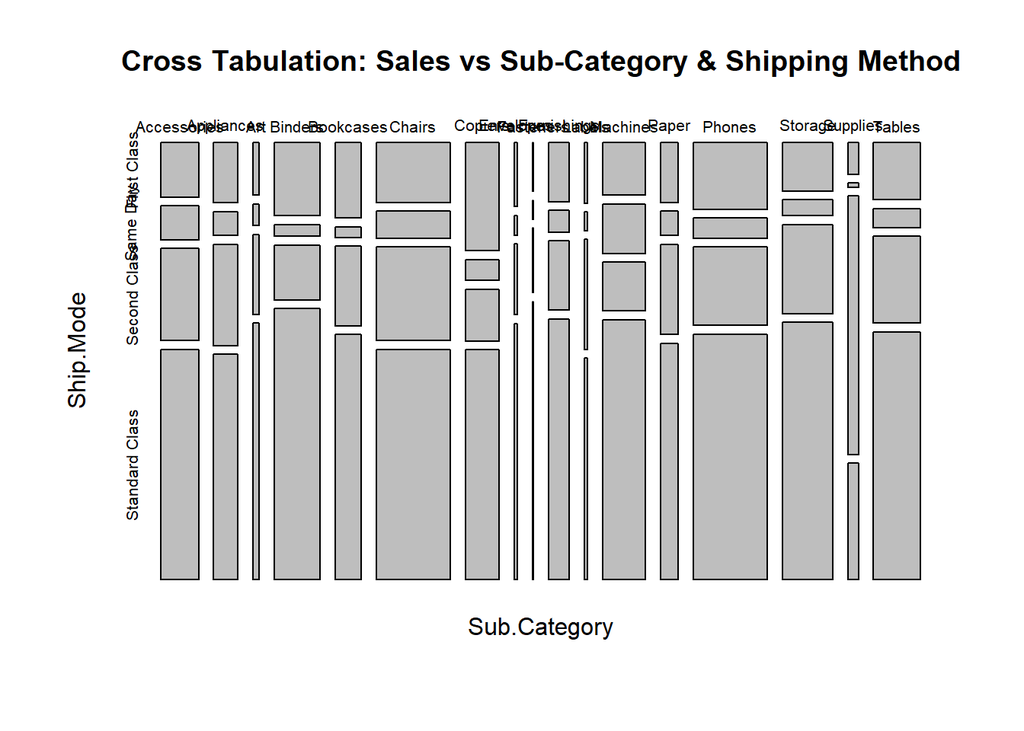

```r
plot(xtabs(Sales ~ Sub.Category + Ship.Mode, retail), main="Cross Tabulation: Sales vs Sub-Category & Shipping Method")
```

Another way to visualize the cross-tabulation above is through the use of heatmap. In R a heatmap is created using the `heatmap` function, so all we need to do is to swap the `plot()` function above with `heatmap()`. I’d also set the heatmap to scale in the column direction - this makes the heatmap output more sensible:

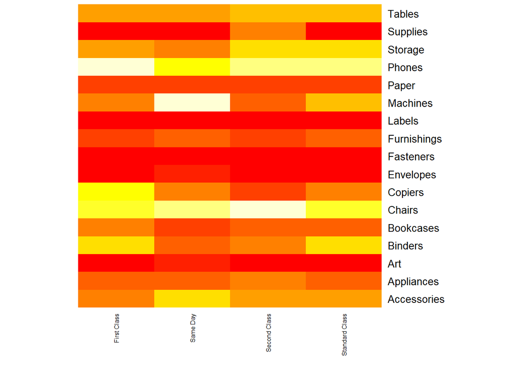

```r
heatmap(xtabs(Sales ~ Sub.Category + Ship.Mode, retail), Colv = NA, Rowv = NA, cexCol = 0.6,scale = "column")
```

Just like how there’s more than one way to create a visual representation of our cross-tabulation data, there are also more than one way to summarize data across multiple variables. We’ve learned about cross-tabulation using `xtabs` earlier but another equally common statistical tool is the aggregate function, using `aggregate`. The function call is almost the same as `xtabs` except is requires an additional parameter, which is the function we want to use for the aggregation:

```r
aggregate(Sales ~ Category + Sub.Category, retail, sum)
```

```
##           Category Sub.Category     Sales
## 1       Technology  Accessories 167380.32
## 2  Office Supplies   Appliances 107532.16
## 3  Office Supplies          Art  27118.79
## 4  Office Supplies      Binders 203412.73
## 5        Furniture    Bookcases 114880.00
## 6        Furniture       Chairs 328449.10
## 7       Technology      Copiers 149528.03
## 8  Office Supplies    Envelopes  16476.40
## 9  Office Supplies    Fasteners   3024.28
## 10       Furniture  Furnishings  91705.16
## 11 Office Supplies       Labels  12486.31
## 12      Technology     Machines 189238.63
## 13 Office Supplies        Paper  78479.21
## 14      Technology       Phones 330007.05
## 15 Office Supplies      Storage 223843.61
## 16 Office Supplies     Supplies  46673.54
## 17       Furniture       Tables 206965.53
```

Compare that to the first few rows of results we obtained from `xtabs()`:

```r
head(xtabs(Sales ~ Sub.Category + Category, retail))
```

```
##              Category
## Sub.Category  Furniture Office Supplies Technology
##   Accessories      0.00            0.00  167380.32
##   Appliances       0.00       107532.16       0.00
##   Art              0.00        27118.79       0.00
##   Binders          0.00       203412.73       0.00
##   Bookcases   114880.00            0.00       0.00
##   Chairs      328449.10            0.00       0.00
```

**Dive Deeper: Analyzing profitability by Category and Shipment Mode**  
Supposed you were assigned by the company to identify the type of transactions that result in the highest profit on average as well as the ones that result in the biggest losses (or lowest profit) per transaction, how would you go about it?

Use the `aggregate()` function with `Sub.Category` and `Ship.Mode`, but replace the `sum` with `mean` so the function finds the “average” profit instead of total profit from each group instead. If you did this correctly, you should observe that Copiers are great profit makers, and that customers that ship Copiers on First Class bags an average profit in excess of $1,200 per transaction. Sweet!

- What are the top 6 groups measured by average profit? Use the `mean` for this.
- What the bottom (worst) 6 groups measured by average profit? Use the `mean` for this.
- Use the answer provided at the end of this course book as reference.

Supposed we have no concern about the average transaction nor the shipment mode, we could change the formula in our `aggregate` function to take a much simpler form. The following code sums profit across each sub-category:

```r
aggregate(Profit ~ Sub.Category, retail, sum)
```

```
##    Sub.Category      Profit
## 1   Accessories  41936.6357
## 2    Appliances  18138.0054
## 3           Art   6527.7870
## 4       Binders  30221.7633
## 5     Bookcases  -3472.5560
## 6        Chairs  26590.1663
## 7       Copiers  55617.8249
## 8     Envelopes   6964.1767
## 9     Fasteners    949.5182
## 10  Furnishings  13059.1436
## 11       Labels   5546.2540
## 12     Machines   3384.7569
## 13        Paper  34053.5693
## 14       Phones  44515.7306
## 15      Storage  21278.8264
## 16     Supplies  -1189.0995
## 17       Tables -17725.4811
```

And we can confirm the above by summing across the row values in our `xtabs` as well, using a handy function called `rowSums`:

```r
as.data.frame(rowSums(xtabs(Profit ~ Sub.Category + Ship.Mode, retail)))
```

```
##             rowSums(xtabs(Profit ~ Sub.Category + Ship.Mode, retail))
## Accessories                                                41936.6357
## Appliances                                                 18138.0054
## Art                                                         6527.7870
## Binders                                                    30221.7633
## Bookcases                                                  -3472.5560
## Chairs                                                     26590.1663
## Copiers                                                    55617.8249
## Envelopes                                                   6964.1767
## Fasteners                                                    949.5182
## Furnishings                                                13059.1436
## Labels                                                      5546.2540
## Machines                                                    3384.7569
## Paper                                                      34053.5693
## Phones                                                     44515.7306
## Storage                                                    21278.8264
## Supplies                                                   -1189.0995
## Tables                                                    -17725.4811
```

# 4 R Scripts and Reproducible Research

**R Script to clean & transform the data**  
Write a R script containing a function (name the function however way you want) that reads `retail.csv` as input, perform the necessary transformation and export a cross-tabulation numeric result OR plot as output. This is the base requirement but more advanced students are free to customize their script to add any extra functionalities.

```r
# Sourcing the scipt and running the function should print a cross-tabulation result or plot
source("lbb1.R")
crstab()
```

For graders: Student scores a maximum 2 out of (2) possible points. Check that the R script executes and return a cross tabulation plot (`plot(xtabs())`) with no errors, warnings or missing variables / values.

**Reproducible Data Science**  
Create an R Markdown file that combines your step-by-step data transformation code with some explanatory text. Add formatting styles and hierarchical structure using Markdown.

For graders: Student scores a maximum 2 out of (2) possible points. Check that the RMD file compiles to HTML with at least **two** headings, **two** explanatory paragraph, and the final output is a business recommendation written in English or Bahasa Indonesia on profitable categories.

Writing your code as R scripts make all of these metrics possible for further automation and integration with other tools and services, while writing a R Markdown presents your findings and recommendations in a way that is friendly to non-technical / managerial team members.

## 4.1 Tips on writing R Scripts and functions

As an example, here’s how you can write a function, named “weeklyreport”:

```r
library(skimr)
library(dplyr)
weeklyreport <- function(){
  retail <- read.csv("data_input/retail.csv")
  retail %>%
  group_by(Segment) %>%
  skim(Category, Profit)
}
```

And now you can call the function you created:

```r
weeklyreport()
```

```
## Skim summary statistics
##  n obs: 9994
##  n variables: 15
##  group variables: Segment
##
## Variable type: factor
##       Segment variable missing complete    n n_unique
## 1    Consumer Category       0     5191 5191        3
## 2   Corporate Category       0     3020 3020        3
## 3 Home Office Category       0     1783 1783        3
##                              top_counts ordered
## 1 Off: 3127, Fur: 1113, Tec: 951, NA: 0   FALSE
## 2  Off: 1820, Fur: 646, Tec: 554, NA: 0   FALSE
## 3  Off: 1079, Fur: 362, Tec: 342, NA: 0   FALSE
##
## Variable type: numeric
##       Segment variable missing complete    n  mean     sd      min  p25
## 1    Consumer   Profit       0     5191 5191 25.84 242.59 -6599.98 1.58
## 2   Corporate   Profit       0     3020 3020 30.46 231.99 -3839.99 1.93
## 3 Home Office   Profit       0     1783 1783 33.82 212.38 -3399.98 1.98
##   median   p75     max
## 1   8.38 28.61 6719.98
## 2   8.69 29.84 8399.98
## 3   9.1  31.56 3919.99
##                                                               hist
## 1 ▁▁▁▇▁▁▁▁
## 2 ▁▁▇▁▁▁▁▁
## 3 ▁▁▁▇▁▁▁▁
```

# 5 Annotations

[^1]: [How R Helps AirBnB make the most of its data](https://peerj.com/preprints/3182.pdf)
[^2]: [Uber Engineering’s Tech Stack: The Foundation](https://eng.uber.com/tech-stack-part-one/)
[^3]: [Microsoft R Open: The Enhanced R Distribution](http://mran.revolutionanalytics.com/rro/)
[^4]: [CausalImpact: A new open-source package for estimating causal effects in time series](https://opensource.googleblog.com/2014/09/causalimpact-new-open-source-package.html)
[^5]: [R at Microsoft](http://blog.revolutionanalytics.com/2015/06/r-at-microsoft.html)